# Лабораторная работа № 4

[figure not shown]

- На экране показан результат соответствующего этапа настройки.

[figure not shown]

- Три интерфейса FRR получили адреса своих подсетей.

[figure not shown]

## Команда show running-config перечисляет три настроенных интерфейса FRR и имя msk-ndbaranov-gw-01

- На экране показан результат соответствующего этапа настройки.

[figure not shown]

## В show interface brief рабочие eth0, eth1 и eth2 имеют состояние up и ожидаемые IPv4-адреса

- На экране показан результат соответствующего этапа настройки.

[figure not shown]

## С PC1 проверена доступность PC2 и серверного узла

- Ping и traceroute подтверждают пересылку между разными сегментами.

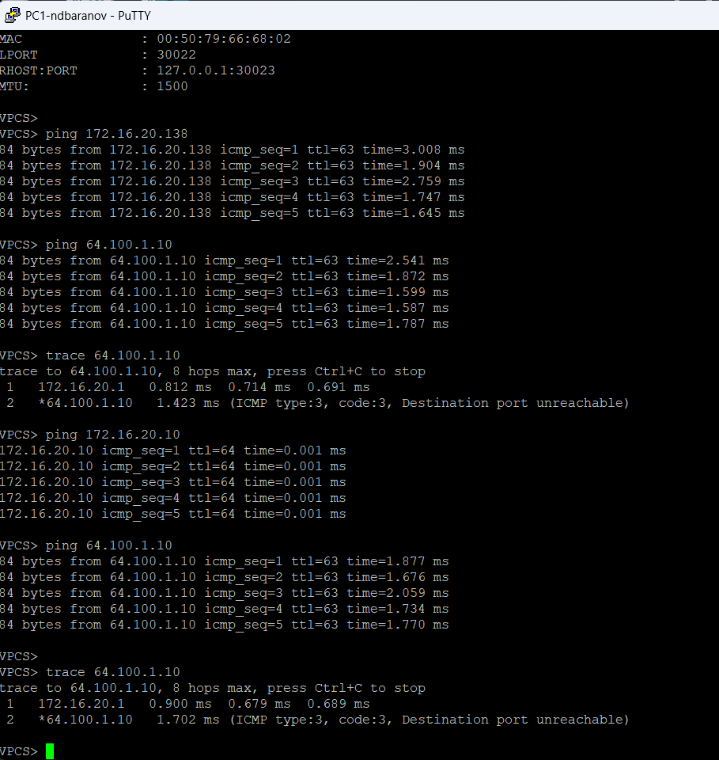

- На экране показан результат соответствующего этапа настройки.

[figure not shown]

- PC4 показан до назначения адресов самостоятельного варианта.

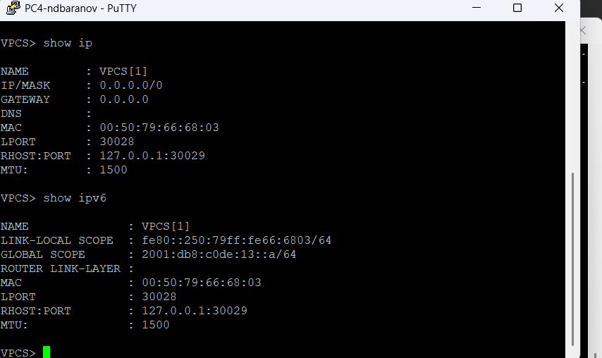

- На экране показан результат соответствующего этапа настройки.

[figure not shown]

## В VyOS удалена автоматическая IPv4-конфигурация eth0, задано имя маршрутизатора и выполнены commit/save

- VyOS подготовлен к настройке двойного стека.

[figure not shown]

## Команда compare отображает добавление трёх IPv6-префиксов на eth0–eth2

- На экране показан результат соответствующего этапа настройки.

[figure not shown]

## После сохранения show interfaces перечисляет IPv6-адреса на каждом Ethernet-интерфейсе VyOS

- После сохранения все IPv6-интерфейсы VyOS подняты.

[figure not shown]

## В Wireshark выделен ARP-обмен в одном из IPv4-сегментов

- На экране показан результат соответствующего этапа настройки.

[figure not shown]

- На экране показан результат соответствующего этапа настройки.

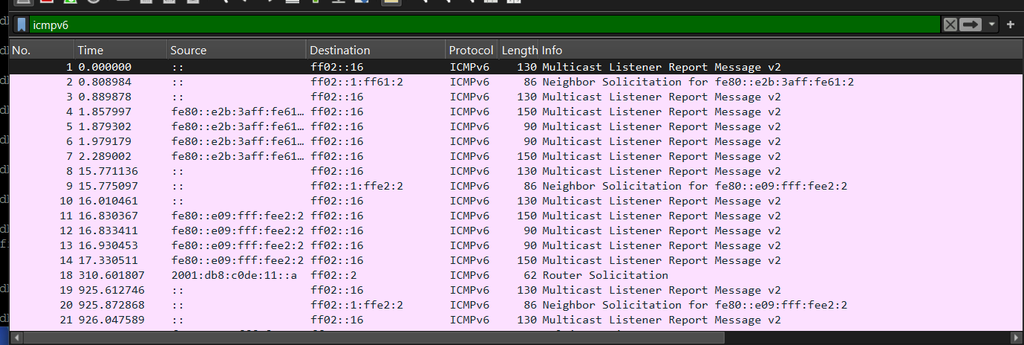

## Для самостоятельной части построена схема с двумя коммутаторами, двумя VPCS и маршрутизатором VyOS

- Самостоятельная схема связывает подсети /27 и /28.

[figure not shown]

- На экране показан результат соответствующего этапа настройки.

[figure not shown]

- PC2 использует 10.10.1.18/28 и префикс 2001:db8:1:4::/64.

[figure not shown]

- На экране показан результат соответствующего этапа настройки.

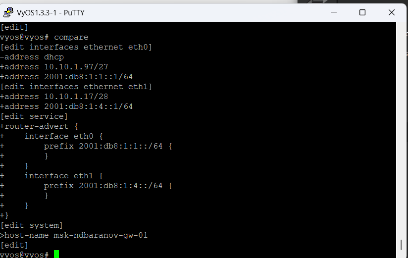

- Итоговая таблица VyOS содержит оба адреса шлюзов.

[figure not shown]

# Результаты

## Итоги работы

- Цель работы достигнута. Распределить адресное пространство и настроить маршрутизацию IPv4/IPv6 между локальными подсетями Полученные результаты подтверждают работоспособность собранной схемы и корректность выполненной настройки.

## Спасибо за внимание